# Problem Set 2

# 2.

## Diff-in-diff

### Pooled OLS

Since the exercise clearly states that the period of analysis goes from 2006 Q1 to 2008 Q2, we restrict the sample for this exercise:

```r
dt_full <- copy(dt) # keep copy of full sample
dt <- dt[date_q %between% c("2006 Q1", "2008 Q2")]
```

Below we first run a difference-in-differences (DiD) model trough pooled OLS. We test a number of model specifications, but the coefficient of interest on `post:D` remains insignificant.

```r
library(stargazer)
dt[,post:=ifelse(date_q<="2007 Q1",0,1)] # define structural break indicator
dt[,D:=ifelse(type=="IRB",1,0)] # define treatment dummy
mod_pooled <- lm(lncredit ~ post * D, data = dt)
mod_pooled_X_macro <- lm(lncredit ~ post * D + mpshock + mprate + gdp + infl, data = dt)
mod_pooled_X_entity <- lm(lncredit ~ post * D + basel_lev + bsizerw_ + bsize_ + rating + empl + fsize, data = dt)
mod_pooled_X_all <- lm(lncredit ~ post * D + mpshock + mprate + gdp + infl + basel_lev + bsizerw_ + bsize_ + rating + empl + fsize, data = dt)
mods <- list(
  mod_pooled,
  mod_pooled_X_entity,
  mod_pooled_X_macro,
  mod_pooled_X_all
)
names(mods) <- c(
  "Simple",
  "Entity controls",
  "Macro controls",
  "Full controls"
)
cov_labels <- gsub("_","",attr(mod_pooled_X_all$terms,"term.labels"))
stargazer(
  mods,
  header = FALSE,
  type = "html",
  column.labels = names(mods),
  covariate.labels = cov_labels
)
```

|  | *Dependent variable:* |  |  |  |
| --- | --- | --- | --- | --- |
|  | lncredit |  |  |  |
|  | Simple | Entity controls | Macro controls | Full controls |
|  | (1) | (2) | (3) | (4) |
| post | -0.0001 | -0.001 | -0.0003 | -0.001 |
|  | (0.008) | (0.008) | (0.016) | (0.016) |
| D | 0.017 | 0.010 | 0.017 | 0.010 |
|  | (0.011) | (0.011) | (0.011) | (0.011) |
| mpshock |  | -0.003* |  | -0.003* |
|  |  | (0.001) |  | (0.001) |
| mprate |  | -0.009 |  | -0.009 |
|  |  | (0.080) |  | (0.080) |
| gdp |  | 0.017 |  | 0.017 |
|  |  | (0.080) |  | (0.080) |
| infl |  | -0.008** |  | -0.008** |
|  |  | (0.003) |  | (0.003) |
| basellev |  | 0.0003* |  | 0.0003* |
|  |  | (0.0002) |  | (0.0002) |
| bsizerw |  | 0.049*** |  | 0.049*** |
|  |  | (0.010) |  | (0.010) |
| bsize |  |  | -0.0004 | -0.0001 |
|  |  |  | (0.031) | (0.031) |
| rating |  |  | 0.001 | -0.0003 |
|  |  |  | (0.044) | (0.044) |
| empl |  |  | 0.00000 | 0.0005 |
|  |  |  | (0.006) | (0.006) |
| fsize |  |  | 0.0001 | 0.0001 |
|  |  |  | (0.005) | (0.005) |
| post:D | 0.011 | 0.006 | 0.011 | 0.005 |
|  | (0.016) | (0.028) | (0.016) | (0.028) |
| Constant | 4.391*** | 3.954*** | 4.388*** | 3.953*** |
|  | (0.006) | (0.086) | (0.197) | (0.214) |
| Observations | 742,590 | 742,590 | 742,590 | 742,590 |
| R<sup>2</sup> | 0.00001 | 0.0001 | 0.00001 | 0.0001 |
| Adjusted R<sup>2</sup> | 0.00001 | 0.0001 | 0.00000 | 0.0001 |
| Residual Std. Error | 2.973 (df = 742586) | 2.973 (df = 742580) | 2.973 (df = 742582) | 2.973 (df = 742576) |
| F Statistic | 2.977** (df = 3; 742586) | 5.740*** (df = 9; 742580) | 1.276 (df = 7; 742582) | 3.975*** (df = 13; 742576) |
| *Note:* | p<0.1; p<0.05; p<0.01 |  |  |  |

### Including firm-bank fixed effects

In the table below we control for firm-bank fixed effects. We find a statistically significant increase in the difference in lending (logs) between IRB and SA banks.

```r
library(lfe)
dt[,firmbank:=paste(firmid,bankid,sep="_")]
mod_fe <- felm(lncredit ~ post * D | firmbank, data = dt)
mod_fe_X_macro <- felm(lncredit ~ post * D + mpshock + mprate + gdp + infl | firmbank, data = dt)
mod_fe_X_entity <- felm(lncredit ~ post * D + basel_lev + bsizerw_ + bsize_ + rating + empl + fsize | firmbank, data = dt)
mod_fe_X_all <- felm(lncredit ~ post * D + mpshock + mprate + gdp + infl + basel_lev + bsizerw_ + bsize_ + rating + empl + fsize | firmbank, data = dt)
mods <- list(
  mod_fe,
  mod_fe_X_entity,
  mod_fe_X_macro,
  mod_fe_X_all
)
names(mods) <- c(
  "Simple",
  "Entity controls",
  "Macro controls",
  "Full controls"
)
cov_labels <- gsub("_","",attr(mod_pooled_X_all$terms,"term.labels"))
stargazer(
  mods,
  header = FALSE,
  type = "html",
  column.labels = names(mods),
  covariate.labels = cov_labels
  # column.sep.width = "-5pt",
  # font.size = "footnotesize"
)
```

|  | *Dependent variable:* |  |  |  |
| --- | --- | --- | --- | --- |
|  | lncredit |  |  |  |
|  | Simple | Entity controls | Macro controls | Full controls |
|  | (1) | (2) | (3) | (4) |
| post | -0.0001 | -0.0001 | -0.0003 | -0.0003 |
|  | (0.0002) | (0.0002) | (0.0003) | (0.0003) |
| D |  |  |  |  |
| mpshock |  | -0.0001 |  | -0.0001 |
|  |  | (0.0002) |  | (0.0002) |
| mprate |  | 0.0003 |  | 0.0003 |
|  |  | (0.002) |  | (0.002) |
| gdp |  | -0.0003 |  | -0.0003 |
|  |  | (0.002) |  | (0.002) |
| infl |  |  |  |  |
| basellev |  | 0.0001*** |  | 0.0001*** |
|  |  | (0.00004) |  | (0.00004) |
| bsizerw |  | -0.001* |  | -0.001* |
|  |  | (0.0004) |  | (0.0004) |
| bsize |  |  | -0.0004 | -0.0004 |
|  |  |  | (0.001) | (0.001) |
| rating |  |  | 0.001 | 0.001 |
|  |  |  | (0.001) | (0.001) |
| empl |  |  | 0.00000 | 0.00000 |
|  |  |  | (0.0001) | (0.0001) |
| fsize |  |  | 0.0001 | 0.00005 |
|  |  |  | (0.0001) | (0.0001) |
| post:D | 0.011*** | 0.011*** | 0.011*** | 0.011*** |
|  | (0.0003) | (0.001) | (0.0003) | (0.001) |
| Observations | 742,590 | 742,590 | 742,590 | 742,590 |
| R<sup>2</sup> | 1.000 | 1.000 | 1.000 | 1.000 |
| Adjusted R<sup>2</sup> | 1.000 | 1.000 | 1.000 | 1.000 |
| Residual Std. Error | 0.056 (df = 668329) | 0.056 (df = 668324) | 0.056 (df = 668325) | 0.056 (df = 668320) |
| *Note:* | p<0.1; p<0.05; p<0.01 |  |  |  |

## Parallel trend

To provide some heuristic evidence for the parallel trend assumption we run the following regression:

$$\begin{aligned}
&& y_{it}&=\sum_{t\ne0} \beta_{t} t^TD_i + \alpha_{ij} + \varepsilon_i \\
\end{aligned}$$
where $t$ is just a vector of time periods, $D_i$ is the treatment dummy and $\alpha_{ij}$ are firm-bank fixed effects.

Figure 3 plots the resulting vector of coefficients $\beta$ along with error bars. We find no divergence in trend of loan growth across small and large bank. Differences show up only upon implementation of the policy.

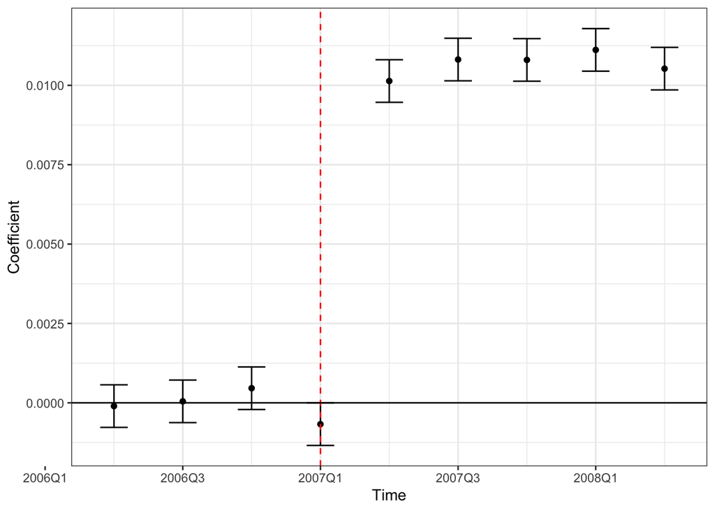

Figure 3: Time-varying coefficient.

```r
alpha <- .05
mod <- summary(felm(lncredit ~ factor(date_q) * D | firmbank, data = dt))
coef <- data.table(mod$coefficients)
coef[,name:=rownames(mod$coefficients)]
coef <- coef[name!="D"]
coef <- coef[grepl(":",name)] # keep only coeffs on interaction term
coef[,date:=dt[,unique(date_q)[-1]]]
setnames(coef, c("Estimate", "Std. Error"), c("estimate", "se"))
p <- ggplot(data = coef, aes(x=date, y=estimate)) +
  geom_errorbar(aes(ymin=estimate-se, ymax=estimate+se), width=.1) +
  geom_point() +
  geom_vline(xintercept = as.yearqtr("2007 Q1"), colour="red", linetype="dashed") +
  geom_hline(yintercept = 0) +
  labs(
    x="Time",
    y="Coefficient"
  ) +
  scale_x_yearqtr(
    format = "%YQ%q"
  )
p
```

# Annex

```r
dt_tab[,post:=ifelse(date_q<="2007 Q1",0,1)]
dt_tab <- dt_tab[,.(value=mean(value)),by=.(type,variable,post)]
dt_tab <- dcast(dt_tab, type + variable ~ post, value.var = "value")
setnames(dt_tab,colnames(dt_tab),c("Bank type", "Leverage ratio", "Pre-treatment", "Post-treatment"))
xtab <- xtable(dt_tab)
print(xtab, type="html")
```

|  | Bank type | Leverage ratio | Pre-treatment | Post-treatment |
| --- | --- | --- | --- | --- |
| 1 | IRB | Tier-1 | 5.97 | 5.99 |
| 2 | IRB | Basel III | 5.97 | 4.48 |
| 3 | SA | Tier-1 | 6.87 | 6.92 |
| 4 | SA | Basel III | 6.87 | 6.91 |